# Lecture 3 - Data Wrangling

# Class Housekeeping

- Show repo main page
- Watch the repo’s issues
- Check on Files Downloads - Don’t forget to download everything in the day’s Lecture folder. Similarly…
- Folder structures: Mimic the main repo’s folder structure. Have a Lectures folder and a Problem Sets folder. Make sure these each have folders within them for the lecture number or problem set, and then have the relevant files within that folder.
  - We’re going to be adding a lot, and it needs to stay organized
  - This lecture and problem set will **require** their own data folder and if it’s not in there correctly your code won’t run.
  - So get that folder structure set up ASAP - just move your files in your local folder and git will track it
- Reminder on how to open up your work in class (always start by opening up your Rproject and you should see the name of the R project in upper right corner)

# Lecture

## Intro discussion

What has been most frustrating in terms of coding or RStudio thus far? How should you learn how to code? How do you learn how to speak another language?

## Data Wrangling

Wrangling is the process of *transforming* or *manipulating* data into useful formats for downstream tasks. Frequently our data:

- Are not in the right format for visualization, modeling, or other analysis
  - Non-rectangular data (e.g., YAML, .json, netcdf) or even lab data sheets - they might have weird formatting, not always tabular

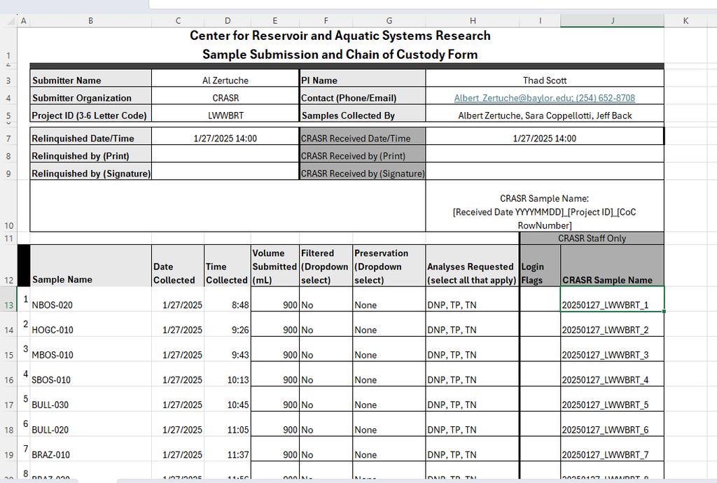

  - Rectangular data but some new variables are needed, columns need to be aggregated, etc. for correct input for modeling or visualization functions
- Are incoherent and messy, obfuscating interpretation (avoid this from the start!)
- Need to be summarized or aggregated in some way (What’s an example of this?)
- Exist across multiple files or dataframes and need **joining**

Why do this in R? Why not do this in Excel?

**Principles for main wrangling tasks:**

- Data import
  - Store data in a sensibly named, accessible folder relative to your code. Where are our data for this lecture? Look at Files tab…
  - Understand file formats (.csv, .txt, .xlsx) - this matters! Different functions used for different formats.
  - Understand provenance: To the best of your ability, keep a copy of raw data untouched

**Caution**

Be aware of the file type of the data you want to load in. We’re working with flat tables in this class, which often are supplied as comma separated values (.csv), plain text (.txt., with some character such as space or tab separating the entries), or Excel (.xls, .xlsx). We will prefer .csv because it’s clear what is separating the values, and because it’s not a proprietary file format, but these are all fine.

`read_csv()` takes the location of a .csv file as its main argument. Same with `read_delim()`, but it needs an additional argument to tell it what character is separating the elements of the table (so you could read a .csv file with this). `read_excel()` has very similar functionality, but can open Excel files, as its name suggests.

- Data manipulation
  - Clean data for future use by you and others
  - Stylized: Create sensible names for variables (and factor levels) easier to remember for analysis (linked to metadata)
    - Make sure variables common to other data frames that you may want to join are named the same (relational database)
    - See [R for Data Science Ch.4](https://r4ds.hadley.nz/workflow-style.html) for some styling tips
  - Represent datetimes interpretably
    - Printing/saving sometimes poorly visualized in R
    - Understand time zones and link this to metadata
  - Summarize data as needed for any analysis/visualization
  - Keep a record of this data manipulation as an R script (.R)/.Rmd/.Qmd
  - Format data to **tidy** conventions

> “Tidy datasets are easy to manipulate, model and visualize…” Wickham (2014)

> A dataset is a collection of values, usually either numbers (if quantitative) or strings AKA text data (if qualitative/categorical). Values are organised in two ways. Every value belongs to a variable and an observation. A variable contains all values that measure the same underlying attribute (like height, temperature, duration) across units. An observation contains all values measured on the same unit (like a person, or a day, or a city) across attributes.
> 1. Each variable forms a column
> 2. Each observation forms a row
> 3. Each type of observational unit forms a table

> Wickham, Çetinkaya-Rundel, and Grolemund (2023)

What this means is tidy data are often ‘long’ format rather than ‘wide’ format.

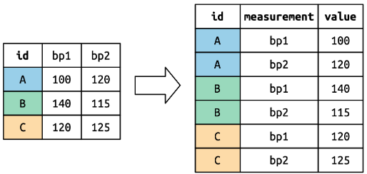

- Data export
  - Store data in a sensibly named, accessible folder relative to your code
  - Choose a sensible file name
  - Store data in a non-proprietary flat file format if you can (e.g., .csv)
  - Understand provenance: Keep a record of key transformed data used in analyses
    - Code also creates a record of this, but in many cases important to save a file you regularly work from

**The upshot: Tidied data stemming from a documented import-manipulation-export wrangling workflow leads to accessibility and usability by future you and others.**

## Key tools for data wrangling

- The tidyverse packages, including dplyr
- split-apply-combine approaches (grouped manipulation)
- pivoting
- piping

### Enter the tidyverse

The [tidyverse](https://tidyverse.org/packages/) is a collection of packages that neatly enable a lot of important data science tasks: data import, wrangling, tidying, visualization, and programming (Wickham et al. 2019). The tidyverse will be the primary “grammar” of R coding you will learn in this course. It differs from base R.

### dplyr verbs

The workhorse package of the tidyverse is [dplyr](https://dplyr.tidyverse.org/), a “grammar of data manipulation” that provides a number of very useful “verbs” (functions) for data manipulation. There will be other functions you need to know but these are central to tidyverse.

**Notedplyr verbs**

- `mutate()` - transforms each value in a column using a function, often algebra, coercion, or text manipulation
- `select()` - conditionally selects columns, usually by matching a name
- `filter()` - primarily operates on rows by conditionally selecting them
- `summarize()` - collapses information about a column using a function, such as `mean()` - usually returns a smaller dataframe
- `arrange()` - orders (sorts) the dataframe by the values in one or more columns

Lots more useful functions exist that we’ll explore, but these are the big ones. [dplyr cheatsheet](https://github.com/rstudio/cheatsheets/blob/main/data-transformation.pdf)

> Each verb does one thing well. The common structure is:
> 1. The first argument is always a data frame.
> 2. The subsequent arguments typically describe which columns to operate on using the variable names (without quotes).
> 3. The output is always a new data frame.

> Wickham, Çetinkaya-Rundel, and Grolemund (2023)

### Split-apply-combine approach

**Split** data into groups - **apply** a function - **combine** them back together.

The split-apply-combine approach to data manipulation is the basis for breaking up data or summaries of data into pieces and then putting them back together (Wickham 2011). Really, we often want to manipulate or summarize data based on group identification. dplyr’s `group_by()` does exactly this - it’s less of a verb and more of a helper function.

What’s an example of a grouped manipulation you might want to code up?

### pivoting

Pivoting is useful when you have observations in your columns. For example, look at this contrived example. Let’s say you set up an experiment where you have two bacterial colonies in petri dishes. You then dose one dish with PFAS and leave the other alone, recording cell counts in each at 10 time points.

```
# A tibble: 10 × 3
   Timepoint Control  PFAS
       <int>   <dbl> <dbl>
 1         1   52740 48570
 2         2   51790 47810
 3         3   61390 51750
 4         4   48680 50000
 5         5   53330 48450
 6         6   47520 47270
 7         7   51150 53680
 8         8   54790 51250
 9         9   48300 40370
10        10   55610 47690
```

Why is this not tidy data? Is each row an observation? There is one timepoint per row, was there one observation per time point? What might actually be useful about this format?

Pivoting allows us to “lengthen” these data, specifically with `pivot_longer()`. Sometimes we need to widen data with `pivot_wider()`, but lengthening is more common. Lengthening here makes our data tidy by making the variable names `Control` and `PFAS` values in a column, with a new name (call it Treatment), describing an attribute of that observation. Then we can have all the cell counts in one column. Notice what happens here:

```r
counts_df|>
  tidyr::pivot_longer(cols = c(Control, PFAS), names_to = "Treatment", values_to = "Cell_Counts")
```

```
# A tibble: 20 × 3
   Timepoint Treatment Cell_Counts
       <int> <chr>           <dbl>
 1         1 Control         52740
 2         1 PFAS            48570
 3         2 Control         51790
 4         2 PFAS            47810
 5         3 Control         61390
 6         3 PFAS            51750
 7         4 Control         48680
 8         4 PFAS            50000
 9         5 Control         53330
10         5 PFAS            48450
11         6 Control         47520
12         6 PFAS            47270
13         7 Control         51150
14         7 PFAS            53680
15         8 Control         54790
16         8 PFAS            51250
17         9 Control         48300
18         9 PFAS            40370
19        10 Control         55610
20        10 PFAS            47690
```

### The pipe operator

A quick aside that will facilitate data wrangling workflows: The **pipe operator**, `|>` (native to base R; preferred) or `%>%` (specific to the tidyverse), basically says “take the output of this function and make it the input of the next function.” It’s a way to (usually) make code more readable as a seamless flow of steps.

**Tip**

The trick to working with pipes, as with any workflow, is to remember to work step by step through your piped code. Let yourself see the intermediaries before you put it all together.

# Code along

A quick setup chunk:

```r
options(max.print = 20) # just so we're not printing a ton of lines when printing vectors
library(here)
here()
```

```
[1] "D:/GitHub_Repos/dev_QuantBio_BIO5324_Sp2026"
```

Let’s load the tidyverse - uncomment *install.packages()* assuming you need to install the collection. Then *library()* will load the collection: Note all the packages that get attached.

```r
#install.packages("tidyverse")
library(tidyverse)
```

## Data import

Let’s first import the data file into our global environment using `read_delim()` and telling the function to parse the file assuming the delimiter is a comma (i.e., a comma-separated values file or .csv - `read_csv()` also exists as a wrapper around this function). `read_csv()` takes the files location as its main argument.

Note that read_csv spits out some messages! That doesn’t mean it didn’t work - they’re somewhat informative.

Notice the file structure: where is this? Open it up and see what separates the values.

```r
flights <- read_delim(here("Lectures/03_Data-Wrangling/Data/Raw Data/nycflights23_flights.csv"), delim = ",")
```

**TipExtra Thinking**

What happens if you use a different delimiter (`delim` argument) here? Why?

These kinds of messages popping up when using data import functions from the tidyverse - What are they telling us? What are the properties of this data? It has 435352 rows with 19 columns. What kind of variable is it?

```r
class(flights)
```

```
[1] "spec_tbl_df" "tbl_df"      "tbl"         "data.frame"
```

A few answers come up, but primarily it is “tbl” and “data.frame”. So this object is recognized by R as a data frame and a specific kind of dataframe known as a tibble. Basically, this is tabular data.

We can get some more info quickly with *glimpse()*, which shows the name of each column

```r
glimpse(flights)
```

```
Rows: 435,352
Columns: 19
$ year           <dbl> 2023, 2023, 2023, 2023, 2023, 2023, 2023, 2023, 2023, 2…
$ month          <dbl> 1, 1, 1, 1, 1, 1, 1, 1, 1, 1, 1, 1, 1, 1, 1, 1, 1, 1, 1…
$ day            <dbl> 1, 1, 1, 1, 1, 1, 1, 1, 1, 1, 1, 1, 1, 1, 1, 1, 1, 1, 1…
$ dep_time       <dbl> 1, 18, 31, 33, 36, 503, 520, 524, 537, 547, 549, 551, 5…
$ sched_dep_time <dbl> 2038, 2300, 2344, 2140, 2048, 500, 510, 530, 520, 545, …
$ dep_delay      <dbl> 203, 78, 47, 173, 228, 3, 10, -6, 17, 2, -10, -9, -7, -…
$ arr_time       <dbl> 328, 228, 500, 238, 223, 808, 948, 645, 926, 845, 905, …
$ sched_arr_time <dbl> 3, 135, 426, 2352, 2252, 815, 949, 710, 818, 852, 901, …
$ arr_delay      <dbl> 205, 53, 34, 166, 211, -7, -1, -25, 68, -7, 4, -13, -14…
$ carrier        <chr> "UA", "DL", "B6", "B6", "UA", "AA", "B6", "AA", "UA", "…
$ flight         <dbl> 628, 393, 371, 1053, 219, 499, 996, 981, 206, 225, 800,…
$ tailnum        <chr> "N25201", "N830DN", "N807JB", "N265JB", "N17730", "N925…
$ origin         <chr> "EWR", "JFK", "JFK", "JFK", "EWR", "EWR", "JFK", "EWR",…
$ dest           <chr> "SMF", "ATL", "BQN", "CHS", "DTW", "MIA", "BQN", "ORD",…
$ air_time       <dbl> 367, 108, 190, 108, 80, 154, 192, 119, 258, 157, 164, 1…
$ distance       <dbl> 2500, 760, 1576, 636, 488, 1085, 1576, 719, 1400, 1065,…
$ hour           <dbl> 20, 23, 23, 21, 20, 5, 5, 5, 5, 5, 5, 6, 5, 6, 6, 6, 6,…
$ minute         <dbl> 38, 0, 44, 40, 48, 0, 10, 30, 20, 45, 59, 0, 59, 0, 0, …
$ time_hour      <dttm> 2023-01-01 20:00:00, 2023-01-01 23:00:00, 2023-01-01 2…
```

So we have 19 variables here, each with a name after *$* And then the type of the variable is given in the *<>*. “dbl” is a type of numeric vector, “chr” is a character vector, and “dttm” is specifically formatted as a datetime. Then the first few entries of each variable are given. You can also get this info without *glimpse()* by looking in the Data pane and clicking the ‘play’ button next to the dataframe object.

Note that we can access individual columns as vectors using the *$* operator.

```r
flights$origin
```

```
 [1] "EWR" "JFK" "JFK" "JFK" "EWR" "EWR" "JFK" "EWR" "EWR" "EWR" "JFK" "LGA"
[13] "LGA" "JFK" "EWR" "EWR" "LGA" "EWR" "LGA" "LGA"
 [ reached getOption("max.print") -- omitted 435332 entries ]
```

We can use this to check out the unique values for variables, including calculating how many destinations are included in the dataset using *unique()* and *length()*.

```r
unique(flights$origin)
```

```
[1] "EWR" "JFK" "LGA"
```

```r
length(unique(flights$dest))
```

```
[1] 118
```

### `|>`

A quick example on our pipe operator

```r
ncol(flights)
```

```
[1] 19
```

```r
class(flights|>ncol())
```

```
[1] "integer"
```

The output here is actually an integer but *Your piped code chains while data wrangling will almost always start with a dataframe, do some stuff to it, and output a dataframe.* A frequent exception to the output is when exporting (writing to file).

**TipExtra Thinking**

Use `distinct()` and the `|>` operator to do the tidyverse version of `unique(flights$origin)`.

## Data manipulation

### dplyr verbs

Remember our dplyr verbs. we’ll work through these one by on and then show how they can be used in ‘grouped’ workflows.

- *mutate()*
- *select()*
- *filter()*
- *summarize()*
- *arrange()*

#### `mutate()`

`mutate()` works on columns, “adding new variables or changing current variables that are functions of existing variables”. So you can set a new variable (or overwrite a current variable). Let’s calculate average air speed in flights (calling it a new variable “speed_km.h”), calculated with a normal algebraic formula, and store the result in a newly named data frame.

```r
flights1 <- flights|>
  mutate(speed_km.h = distance / air_time * 60,
         .before = 1)
flights1
```

```
# A tibble: 435,352 × 20
   speed_km.h  year month   day dep_time sched_dep_time dep_delay arr_time
        <dbl> <dbl> <dbl> <dbl>    <dbl>          <dbl>     <dbl>    <dbl>
 1       409.  2023     1     1        1           2038       203      328
 2       422.  2023     1     1       18           2300        78      228
 3       498.  2023     1     1       31           2344        47      500
 4       353.  2023     1     1       33           2140       173      238
 5       366   2023     1     1       36           2048       228      223
 6       423.  2023     1     1      503            500         3      808
 7       493.  2023     1     1      520            510        10      948
 8       363.  2023     1     1      524            530        -6      645
 9       326.  2023     1     1      537            520        17      926
10       407.  2023     1     1      547            545         2      845
# ℹ 435,342 more rows
# ℹ 12 more variables: sched_arr_time <dbl>, arr_delay <dbl>, carrier <chr>,
#   flight <dbl>, tailnum <chr>, origin <chr>, dest <chr>, air_time <dbl>,
#   distance <dbl>, hour <dbl>, minute <dbl>, time_hour <dttm>
```

Note that mutate is working row-by-row to do the calculation with values in the named columns.

What if we wanted to create a new variable that showed the origin and destination of each flight? We can work with characters, just not numerically. *str_c()* works to concatenate a string. It will take quoted strings as literal, but unquoted words it will look for a variable and use that value:

```r
flights2 <- flights1|>
  mutate(route = str_c(origin, "-to-", dest),
         .before = 1)
flights2
```

```
# A tibble: 435,352 × 21
   route speed_km.h  year month   day dep_time sched_dep_time dep_delay arr_time
   <chr>      <dbl> <dbl> <dbl> <dbl>    <dbl>          <dbl>     <dbl>    <dbl>
 1 EWR-…       409.  2023     1     1        1           2038       203      328
 2 JFK-…       422.  2023     1     1       18           2300        78      228
 3 JFK-…       498.  2023     1     1       31           2344        47      500
 4 JFK-…       353.  2023     1     1       33           2140       173      238
 5 EWR-…       366   2023     1     1       36           2048       228      223
 6 EWR-…       423.  2023     1     1      503            500         3      808
 7 JFK-…       493.  2023     1     1      520            510        10      948
 8 EWR-…       363.  2023     1     1      524            530        -6      645
 9 EWR-…       326.  2023     1     1      537            520        17      926
10 EWR-…       407.  2023     1     1      547            545         2      845
# ℹ 435,342 more rows
# ℹ 12 more variables: sched_arr_time <dbl>, arr_delay <dbl>, carrier <chr>,
#   flight <dbl>, tailnum <chr>, origin <chr>, dest <chr>, air_time <dbl>,
#   distance <dbl>, hour <dbl>, minute <dbl>, time_hour <dttm>
```

The .before = 1 argument just places the resulting column that we define before the first column. This makes it easier for visualization because there are 21 variables here now. But maybe we don’t want all those variables!…

Although there is a datetime variable already in flights (notice its class is POSIXct), let’s use mutate to create a date vector from the Year, month and day variables. `as_date()` can convert characters to dates **if** it can parse the format. YMD (year-month-day) is the ordering that is safe and you should present/save dates as.

```r
(flights_with_date <- flights2|>
  mutate(date = as_date(str_c(year, "-",month,"-",day)),
  relocate(date)))
```

[output not shown]

**TipExtra Thinking**

What’s the timezone for the time_hour variable of the `flights` data?

#### `select()`

*select()* selects columns by name, and the ordering of the names can be used to reorder the columns.

```r
flights2|>
  select(year, route, speed_km.h)
```

```
# A tibble: 435,352 × 3
    year route      speed_km.h
   <dbl> <chr>           <dbl>
 1  2023 EWR-to-SMF       409.
 2  2023 JFK-to-ATL       422.
 3  2023 JFK-to-BQN       498.
 4  2023 JFK-to-CHS       353.
 5  2023 EWR-to-DTW       366
 6  2023 EWR-to-MIA       423.
 7  2023 JFK-to-BQN       493.
 8  2023 EWR-to-ORD       363.
 9  2023 EWR-to-IAH       326.
10  2023 EWR-to-FLL       407.
# ℹ 435,342 more rows
```

This can be done by negation.

```r
flights2|>
  select(-route, -speed_km.h, -year)
```

```
# A tibble: 435,352 × 18
   month   day dep_time sched_dep_time dep_delay arr_time sched_arr_time
   <dbl> <dbl>    <dbl>          <dbl>     <dbl>    <dbl>          <dbl>
 1     1     1        1           2038       203      328              3
 2     1     1       18           2300        78      228            135
 3     1     1       31           2344        47      500            426
 4     1     1       33           2140       173      238           2352
 5     1     1       36           2048       228      223           2252
 6     1     1      503            500         3      808            815
 7     1     1      520            510        10      948            949
 8     1     1      524            530        -6      645            710
 9     1     1      537            520        17      926            818
10     1     1      547            545         2      845            852
# ℹ 435,342 more rows
# ℹ 11 more variables: arr_delay <dbl>, carrier <chr>, flight <dbl>,
#   tailnum <chr>, origin <chr>, dest <chr>, air_time <dbl>, distance <dbl>,
#   hour <dbl>, minute <dbl>, time_hour <dttm>
```

..and even by position. The *select()* help file shows other ways of selecting variables using [tidyselect](https://tidyselect.r-lib.org/index.html) syntax.

```r
flights2|>
  select(1,2)
```

```
# A tibble: 435,352 × 2
   route      speed_km.h
   <chr>           <dbl>
 1 EWR-to-SMF       409.
 2 JFK-to-ATL       422.
 3 JFK-to-BQN       498.
 4 JFK-to-CHS       353.
 5 EWR-to-DTW       366
 6 EWR-to-MIA       423.
 7 JFK-to-BQN       493.
 8 EWR-to-ORD       363.
 9 EWR-to-IAH       326.
10 EWR-to-FLL       407.
# ℹ 435,342 more rows
```

#### `filter()`

`filter()` works by **conditionally** selecting rows in the dataframe where some condition is met. Let’s filter flights only that came out of JFK and select a few columns.

```r
flights_jfk <- flights2|>
  filter(origin == "JFK")|>
  select(speed_km.h, year,month, day, origin, route)
flights_jfk
```

```
# A tibble: 133,048 × 6
   speed_km.h  year month   day origin route
        <dbl> <dbl> <dbl> <dbl> <chr>  <chr>
 1       422.  2023     1     1 JFK    JFK-to-ATL
 2       498.  2023     1     1 JFK    JFK-to-BQN
 3       353.  2023     1     1 JFK    JFK-to-CHS
 4       493.  2023     1     1 JFK    JFK-to-BQN
 5       376.  2023     1     1 JFK    JFK-to-PBI
 6       387.  2023     1     1 JFK    JFK-to-MIA
 7       494.  2023     1     1 JFK    JFK-to-SJU
 8       447.  2023     1     1 JFK    JFK-to-SEA
 9       396.  2023     1     1 JFK    JFK-to-PHX
10       403.  2023     1     1 JFK    JFK-to-MIA
# ℹ 133,038 more rows
```

We can see this now has a significantly reduced number of rows (133048) because we’ve excluded the rows where the origin is NOT JFK. Note that *==* is the equality operator - filtering uses logic, evaluating each possibility as TRUE/FALSE conditional statements. `filter(origin == "JFK")` implies we are looking for cases where origin is EXACTLY matching the string “JFK”. We could also do `filter(origin != "JFK")` or select multiple conditions using operators like *<* (less than) or *<=* (less than or equal to) or *&* (AND operator) or *|* (OR operator).

Let’s use filter to find NA cases of `speed_km.h`.

```r
flights2|>
  filter(is.na(speed_km.h))
```

```
# A tibble: 12,534 × 21
   route speed_km.h  year month   day dep_time sched_dep_time dep_delay arr_time
   <chr>      <dbl> <dbl> <dbl> <dbl>    <dbl>          <dbl>     <dbl>    <dbl>
 1 EWR-…         NA  2023     1     1      753            730        23     1211
 2 JFK-…         NA  2023     1     1      949            900        49       NA
 3 LGA-…         NA  2023     1     1     2000           1959         1     1537
 4 EWR-…         NA  2023     1     1     2151           2159        -8     1110
 5 LGA-…         NA  2023     1     1       NA           2245        NA       NA
 6 EWR-…         NA  2023     1     1       NA           1655        NA       NA
 7 EWR-…         NA  2023     1     1       NA            920        NA       NA
 8 LGA-…         NA  2023     1     1       NA            959        NA       NA
 9 EWR-…         NA  2023     1     1       NA           2030        NA       NA
10 LGA-…         NA  2023     1     2      711            715        -4     1313
# ℹ 12,524 more rows
# ℹ 12 more variables: sched_arr_time <dbl>, arr_delay <dbl>, carrier <chr>,
#   flight <dbl>, tailnum <chr>, origin <chr>, dest <chr>, air_time <dbl>,
#   distance <dbl>, hour <dbl>, minute <dbl>, time_hour <dttm>
```

**TipExtra Thinking**

Why would speed be NA?

#### `arrange()`

`arrange()` orders/sorts rows according to the values of selected columns. Let’s arrange the data frame to view the worst delays first. `arrange()` will by default arrange in numeric order, but we actually want the largest values first so we use `desc()` to get the descending order of the variable to arrange on. Let’s also turn this variable into hours rather than minutes.

```r
flights2 |>
  mutate(dep_delay_h = dep_delay/60)|>
  arrange(desc(dep_delay_h))|>
  relocate(dep_delay_h) #relocate can move columns without selecting, by default it does to the front of the line
```

```
# A tibble: 435,352 × 22
   dep_delay_h route      speed_km.h  year month   day dep_time sched_dep_time
         <dbl> <chr>           <dbl> <dbl> <dbl> <dbl>    <dbl>          <dbl>
 1        30.2 EWR-to-CLT       369.  2023    12    17     1953           1340
 2        29.7 EWR-to-ORD       423.  2023    10     1     1240            659
 3        29.0 LGA-to-DCA       306.  2023     4    25     1201            659
 4        27.8 LGA-to-DFW       374.  2023     2     7     2045           1700
 5        27.1 JFK-to-CLT       406.  2023     4    20      926            619
 6        26.9 LGA-to-CLT       375.  2023    10    29      856            600
 7        26.0 JFK-to-CLT       396.  2023     4    30     1818           1617
 8        26.0 EWR-to-DFW       386.  2023     3    17     2027           1830
 9        25.1 EWR-to-ORD       332.  2023     3    29      633            525
10        23.9 EWR-to-ORD       385.  2023     3    19     1154           1201
# ℹ 435,342 more rows
# ℹ 14 more variables: dep_delay <dbl>, arr_time <dbl>, sched_arr_time <dbl>,
#   arr_delay <dbl>, carrier <chr>, flight <dbl>, tailnum <chr>, origin <chr>,
#   dest <chr>, air_time <dbl>, distance <dbl>, hour <dbl>, minute <dbl>,
#   time_hour <dttm>
```

Some of these delays are over a day! Why not just cancel at that point?

#### `summarize()`

`summarize()` works on the whole dataframe, reducing it into a summarization. It works a lot like mutate. What’s the average airspeed and variation as maximum and minimum speed of flights, and the median departure delay, from JFK to Dallas (DFW)? We can define new variables (mean_speed, min_speed, max_speed, median_delay) as *functions of existing variables*, here `mean()`, `max()`, `min()`, and `median()` will be used to summarize the variable - there are a couple of NAs in speed_km.h, but we’ll just ignore them with na.rm = TRUE.

```r
flights2|>
  filter(dest == "DFW", origin == "JFK")|>
  summarize(mean_speed = mean(speed_km.h, na.rm = TRUE),
            max_speed = max(speed_km.h, na.rm = TRUE),
            min_speed = min(speed_km.h, na.rm = TRUE),
            median_delay = median(dep_delay, na.rm = TRUE))
```

```
# A tibble: 1 × 4
  mean_speed max_speed min_speed median_delay
       <dbl>     <dbl>     <dbl>        <dbl>
1       424.      522.      252.           -1
```

So now we have reduced our dataframe to just one row.

Summarize is much more useful when done on groups of data, which we’ll work on next…